**Deep Q-Learning**

By Prof. Seungchul Lee  
http://iai.postech.ac.kr/  
Industrial AI Lab at POSTECH

Table of Contents

# 1. Q-Learning

## 1.1. Optimal control

Given an MDP $(S, A, P, R, \gamma)$, find the optimal policy $\pi^{*}$

- Exact methods
  - value iteration
  - policy iteration
- Limitations
  - Update equations require access to dynamics model $\Rightarrow$ sampling-based approximations
  - Iteration over/storage for all states and actions: require small, discrete state-action space $\Rightarrow$ Q/V function fitting

**Value iteratoin**

$$v (s) = R(s) + \gamma \max_{a} \sum_{s' \in S} P_{s s'}^{a} \; v \left(s' \right)$$

1) Initialize an estimate for the value function arbitrarily

$$ v(s) \leftarrow 0 \quad \forall s \in S $$

2) Repeat, update

$$v (s) \leftarrow R(s) + \gamma \max_{a} \sum_{s' \in S} P_{s s'}^{a} \; v \left(s' \right), \quad \forall s \in S$$

## 1.2. Q-Values

$Q^{*}(s,a) = $ exptected total return starting in state $s$, taking action $a$, and (thereafter) acting optimally

Be carefully with the `max` location in the following equations.

- Bellman equation

$$ Q^{*}(s,a) = R(s) + \gamma \sum_{s' \in S}P_{s s'}^{a} \max_{a \in A} Q^{*}(s',a') $$

- Q-Value iteration

$$ Q_{k+1}(s,a) \leftarrow R(s) + \gamma \sum_{s' \in S}P_{s s'}^{a} \max_{a \in A} Q_{k}(s',a') $$

## 1.3. (Tabular) Q-Learning

Q-value iterations

$$ \begin{align*} Q_{k+1}(s,a) &\leftarrow R(s) + \gamma \sum_{s' \in S}P_{s s'}^{a} \max_{a \in A} Q_{k}(s',a') \\\\ &\leftarrow 1 \cdot R(s) + \gamma \sum_{s' \in S}P_{s s'}^{a} \max_{a \in A} Q_{k}(s',a') \\\\ &\leftarrow \sum_{s' \in S}P_{s s'}^{a} \cdot R(s) + \gamma \sum_{s' \in S}P_{s s'}^{a} \max_{a \in A} Q_{k}(s',a') \\\\ &\leftarrow \sum_{s' \in S}P_{s s'}^{a} \left[ R(s) + \gamma \max_{a \in A} Q_{k}(s',a') \right] \end{align*} $$

Rewrite as expectation

$$ Q_{k+1} \leftarrow \mathbb{E}_{s' \sim P_{s s'}^{a}} \left[ R(s) + \gamma \max_{a \in A} Q_{k}(s',a') \right] $$

**(Tabular) Q-Learning: replace expectation by samples**

1) For an state-action pair $(s,a)$, receive: $s' \sim P_{s s'}^{a}$

2) Consider your old estimate: $Q_k(s,a)$

3) Consider your new sample estimate:
$$\text{target}(s') = R(s) + \gamma \max_{a'}Q_k{(s',a')}$$

4) Incorporate the new estimate into a running average [Temporal Difference or learning incrementally]:
$$ \begin{align*} Q_{k+1}(s,a) \; & \leftarrow \; Q_k(s,a) + \alpha \; \left(\text{target}(s') - Q_k(s,a) \right) \\ &\; = \,\, (1-\alpha) \; Q_k(s,a) + \alpha \;\text{target}(s') \end{align*}$$

How to sample actions (Exploration vs. Exploitation) ?

- Choose random actions ?
- Choose action that maximizes $Q_k(s,a)$ (i.e., greedily) ?
- $\varepsilon$-Greedy: choose random action with probability $\varepsilon$, otherwise choose action greedily

Q-Learning Properties

- Amazing result: Q-learning converges to optimal policy if all state-action pairs seen frequently enough
- With Q-learning, we can learn optimal policy without model of MDP
- This is called off-policy learning

## 1.4. Q-Learning with Gym Environment

- Agent interaction with environment

[figure not shown]

- [OpenAI Gym](https://gym.openai.com/)
  - A Python API for RL environments
  - A set of tools to measure agent performance
  - Read https://gym.openai.com/docs/
- Examples

[figure not shown]

```python
!pip install gym
```

```
You are using pip version 19.0.3, however version 19.1.1 is available.
```

```python
import numpy as np
import matplotlib.pyplot as plt
import tensorflow as tf

from IPython import display
from six.moves import cPickle

import gym
# import pyglet
%matplotlib inline
```

- A pole is attached by an un-actuated joint to a cart, which moves along a frictionless track. The system is controlled by applying a force of +1 or -1 to the cart. The pendulum starts upright, and the goal is to prevent it from falling over. A reward of +1 is provided for every timestep that the pole remains upright. The episode ends when the pole is more than 15 degrees from vertical, or the cart moves more than 2.4 units from the center.

[figure not shown]

- Objective:
  - Balance a pole on top of a movable cart
- State:
  - [position, horizontal velocity, angle, angular speed]
- Action:
  - horizontal force applied on the cart (binary)
- Reward:
  - 1 at each time step if the pole is upright

```python
env = gym.make('CartPole-v0')
env.reset()
```

```
array([-0.03952286, -0.033043  ,  0.0446717 , -0.0173778 ])
```

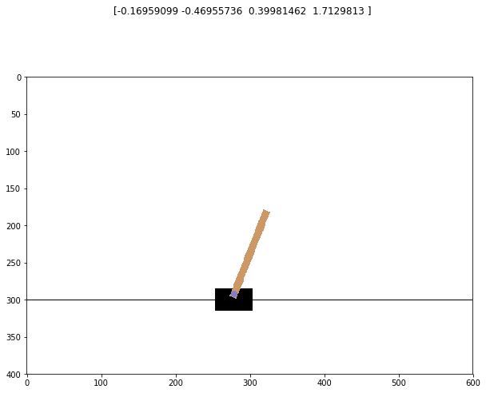

```python
fig = plt.figure(figsize = (10,8))
img = plt.imshow(env.render(mode = 'rgb_array')) # only call this once

for _ in range(40):
    img.set_data(env.render(mode = 'rgb_array')) # just update the data
    display.display(plt.gcf())
    display.clear_output(wait = True)
    action = env.action_space.sample()
    state,_,_,_ = env.step(action)
    fig.suptitle(state)
env.close()
```

$$Q(s,a) \leftarrow (1-\alpha )Q(s,a) + \alpha[r+\gamma \max_{a'}Q(s',a')]$$

Cartpole state = [pos, vel_pos, angle, vel_ang]

```python
print(env.observation_space.low)
print(env.observation_space.high)
```

```
[-4.8000002e+00 -3.4028235e+38 -4.1887903e-01 -3.4028235e+38]
[4.8000002e+00 3.4028235e+38 4.1887903e-01 3.4028235e+38]
```

```python
n_actions = env.action_space.n
print(n_actions)
```

```
2
```

```python
n_bins_pos = 10
n_bins_vel = 5
n_bins_ang = 10
n_bins_anv = 5
```

```python
Q_table = np.random.uniform(0, 1, (n_bins_pos*n_bins_vel*n_bins_ang*n_bins_anv, n_actions))
```

```python
def cal_idx_state(state):
    pos, vel, ang, anv = state

    idx_pos = np.where(np.histogram(np.clip(pos,-2,2), bins = n_bins_pos, range = (-2,2))[0] == 1)[0][0]
    idx_vel = np.where(np.histogram(np.clip(vel,-2,2), bins = n_bins_vel, range = (-2,2))[0] == 1)[0][0]
    idx_ang = np.where(np.histogram(np.clip(ang,-0.418,0.418), bins = n_bins_ang, range = (-0.418,0.418))[0] == 1)[0][0]
    idx_anv = np.where(np.histogram(np.clip(anv,-2,2), bins = n_bins_anv, range = (-2,2))[0] == 1)[0][0]

    idx_state = (n_bins_vel*n_bins_ang*n_bins_anv)*idx_pos + (n_bins_ang*n_bins_anv)*idx_vel + (n_bins_anv)*idx_ang  + idx_anv

    return idx_state
```

```python
LR = 0.5
gamma = 0.99
```

```python
env = gym.make('CartPole-v0')
state = env.reset()

frame = 0
episode = 0
complete_episodes = 0

while True:

    idx_state = cal_idx_state(state)

    # Exploration vs. Exploitation
    epsilon = 0.5 * (1 / (episode + 1))
    if np.random.random(1)[0] < epsilon:
        action = np.random.randint(2)
    else:
        action = np.argmax(Q_table[idx_state])

    new_state, _, done, _ = env.step(action)

    if done:
        if frame >= 199:
            reward = 1
            complete_episodes += 1
        else:
            reward = -1
            complete_episodes = 0

        frame = 0
        new_state = env.reset()
        episode += 1

    else:
        reward = 0

    if complete_episodes >= 10:
        print('Complete!')
        break

    new_idx_state = cal_idx_state(new_state)

    # Temporal Difference Update
    Q_table[idx_state, action] = (1-LR)*Q_table[idx_state, action] + LR*(reward + gamma*np.max(Q_table[new_idx_state,:]))

    state = new_state

    frame += 1

env.close()
```

```
Complete!
```

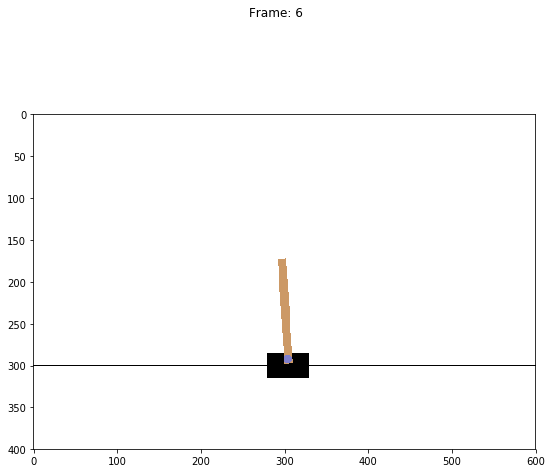

```python
frame = 0
episode = 0
complete_episodes = 0

fig = plt.figure(figsize = (9,8))
img = plt.imshow(env.render(mode = 'rgb_array'))

for _ in range(100):
    img.set_data(env.render(mode = 'rgb_array'))
    display.display(plt.gcf())
    display.clear_output(wait = True)

    idx_state = cal_idx_state(state)
    action = np.argmax(Q_table[idx_state])
    new_state, _, done, _ = env.step(action)

    if abs(state[0]) > 2.7 or abs(state[2]) > 0.45:
        frame = 0
        new_state = env.reset()

    state = new_state
    fig.suptitle('Frame: {}'.format(frame))
    frame += 1

env.close()
```

# 2. Deep Q-Learning (DQN, optional)

Value iteration algorithm: use Bellman equation as an iterative update

$$ Q_{k+1} \leftarrow \mathbb{E}_{s' \sim P_{s s'}^{a}} \left[ R(s) + \gamma \max_{a \in A} Q_{k}(s',a') \right] $$

$Q_k$ will converge to $Q^*$ as $k$ goes to $\infty$

**What is the problem with this?**

- Not scalable. Must compute $Q(s,a)$ for every state-action pair. If state is for instance current game state pixels, computationally infeasible to compute for entire state space !
  - too many states to visit them all in training
  - too many states to hold the Q-table in memory
- States in Tetris: naive board configuration + shape of the falling piece $\sim 10^{60}$ states !!!

[figure not shown]

- Solution: use a function approximator to estimate $Q(s,a)$
  - learn about some small number of training states from experience
  - generalize that experience to new, similar situations

## 2.1. Approximate Q-Learning

Instead of a table, we have a parameterized Q function: $Q_{\omega}(s,a) \approx Q^*(s,a)$

- can be a linear function in features

$$Q_{\omega}(s,a) = \omega_0 f_0(s,a) + \omega_1 f_1(s,a) + \cdots + \omega_n f_n(s,a)$$

- or a complicated neural network $\rightarrow$ (Deep Q-learning Network)

Learning rule:

- remember:

$$\text{target}(s') = R(s) + \gamma \max_{a'}Q_{\omega}{(s',a')}$$

- loss function by mean-squared errow in Q-value

$$\ell(\omega) = \left[ \frac{1}{2} \left(Q_{\omega}(s,a) - \text{target}(s') \right)^2 \right]$$

- update:

$$\omega_{k+1} \leftarrow \omega_k -\alpha \; \nabla_{\omega} \left[ \frac{1}{2} \left(Q_{\omega}(s,a) - \text{target}(s') \right)^2 \right]$$

## 2.2. DQN Architecture

- (Tabular) Q-Learning like DQN, but inefficient

[figure not shown]

- Better DQN

[figure not shown]

```python
import numpy as np
import matplotlib.pyplot as plt
import tensorflow as tf

from IPython import display
from six.moves import cPickle
import random

import gym
import pyglet
%matplotlib inline
```

```python
env = gym.make('CartPole-v0')
env.reset()
```

```
array([ 0.0215885 , -0.01894676,  0.03317834, -0.03992529])
```

```python
n_actions = env.action_space.n
```

```python
n_memory = 5000

n_states = 4
n_Q_value = 2

n_hidden1 = 100
n_hidden2 = 100

epsilon_max = 0.5
gamma = 0.99

LR = 2e-4
max_episodes = 30000
n_training_per_sampling = 200
n_batch = 50
```

```python
ph_states = tf.placeholder(tf.float32, [None, n_states])
ph_Q_target = tf.placeholder(tf.float32, [n_batch])
ph_action = tf.placeholder(tf.int32, [n_batch])
```

```python
with tf.variable_scope('weights'):
    w_hidden1 = tf.get_variable('hidden1', [n_states, n_hidden1], initializer = tf.random_normal_initializer(stddev = 0.01))
    w_hidden2 = tf.get_variable('hidden2', [n_hidden1, n_hidden2], initializer = tf.random_normal_initializer(stddev = 0.01))
    w_output = tf.get_variable('output', [n_hidden2, n_Q_value], initializer = tf.random_normal_initializer(stddev = 0.01))

with tf.variable_scope('biases'):
    b_hidden1 = tf.get_variable('hidden1', [n_hidden1], initializer = tf.random_normal_initializer(stddev = 0.01))
    b_hidden2 = tf.get_variable('hidden2', [n_hidden2], initializer = tf.random_normal_initializer(stddev = 0.01))
    b_output = tf.get_variable('output', [n_Q_value], initializer = tf.random_normal_initializer(stddev = 0.01))
```

```python
def net(states):
    hidden1 = tf.add(tf.matmul(states, w_hidden1), b_hidden1)
    hidden1 = tf.nn.relu(hidden1)

    hidden2 = tf.add(tf.matmul(hidden1, w_hidden2), b_hidden2)
    hidden2 = tf.nn.relu(hidden2)

    output = tf.add(tf.matmul(hidden2, w_output), b_output)
    return output
```

```python
Q = net(ph_states)

loss = tf.reduce_mean([tf.square(ph_Q_target[i] - Q[i][action]) for i, action in enumerate(tf.unstack(ph_action))])

optm = tf.train.AdamOptimizer(LR).minimize(loss)
```

```python
sess = tf.Session()
sess.run(tf.global_variables_initializer())

env = gym.make('CartPole-v0')
state = env.reset()

memory = []
history_frame = []
history_loss = []

for episode in range(max_episodes):
    done = False
    frame = 0
    env.reset()
    while not done:

        epsilon = epsilon_max*(1/(episode/50 + 1))

        if np.random.random(1)[0] < epsilon:
            action = env.action_space.sample()
        else:
            Q_pred = sess.run(Q, feed_dict = {ph_states: state[np.newaxis,:]})
            action = np.argmax(Q_pred,1)[0]

        next_state, _, done, _ = env.step(action)

        if done:
            if frame < 190: reward = -1
            else: reward = 1
        else:
            reward = 0

        memory.append([state, action, reward, next_state, done])
        state = next_state

        if len(memory) > n_memory:
            memory.pop(0)

        frame += 1

    history_frame.append(frame)
    if len(history_frame) >= 10:
        print('avg frame of last 10 episode: {}'.format(np.mean(history_frame[-10:])))
        if np.mean(history_frame[-10:]) > 195:
            print('Loss: {}'.format(sess.run(loss,feed_dict = {ph_states:batch_state, ph_Q_target: batch_Q_target, ph_action: batch_action})))
            print('Epsilon: {:.2f}'.format(epsilon))
            break

    for _ in range(n_training_per_sampling):
        mini_batch = [random.choice(memory) for _ in range(n_batch)]

        batch_state = []
        batch_action = []
        batch_Q_target = []
        for state, action, reward, next_state,done in mini_batch:
            if done:
                batch_Q_target.append(reward)
            else:
                batch_Q_target.append(reward + gamma*np.max(sess.run(Q, feed_dict = {ph_states: next_state[np.newaxis,:]})))

            batch_state.append(state)
            batch_action.append(action)

        sess.run(optm, feed_dict = {ph_states:batch_state, ph_Q_target: batch_Q_target, ph_action: batch_action})

    my_loss = sess.run(loss,feed_dict = {ph_states:batch_state, ph_Q_target: batch_Q_target, ph_action: batch_action})
    history_loss.append(my_loss)
    print('Loss: {}'.format(my_loss))
    print('Epsilon: {:.2f}'.format(epsilon))
```

```
Loss: 0.0005464731366373599
Epsilon: 0.50
Loss: 0.0017118608811870217
Epsilon: 0.49
Loss: 0.009673732332885265
Epsilon: 0.48
Loss: 0.006474871654063463
Epsilon: 0.47
Loss: 0.004048484843224287
Epsilon: 0.46
Loss: 0.014667490497231483
Epsilon: 0.45
Loss: 0.005136826075613499
Epsilon: 0.45
Loss: 0.0017549816984683275
Epsilon: 0.44
Loss: 0.0004873099096585065
Epsilon: 0.43
avg frame of last 10 episode: 69.5
Loss: 0.00021270103752613068
Epsilon: 0.42
avg frame of last 10 episode: 80.0
Loss: 0.00037068050005473197
Epsilon: 0.42
avg frame of last 10 episode: 91.1
Loss: 0.006552546750754118
Epsilon: 0.41
avg frame of last 10 episode: 108.3
Loss: 0.001778863021172583
Epsilon: 0.40
avg frame of last 10 episode: 117.7
Loss: 0.00048239080933853984
Epsilon: 0.40
avg frame of last 10 episode: 129.9
Loss: 0.008119692094624043
Epsilon: 0.39
avg frame of last 10 episode: 140.6
Loss: 0.02412582002580166
Epsilon: 0.38
avg frame of last 10 episode: 154.3
```

[output cut: 47 more lines]

```
avg frame of last 10 episode: 194.0
Loss: 0.009328493848443031
Epsilon: 0.30
avg frame of last 10 episode: 194.0
Loss: 0.00016732745280023664
Epsilon: 0.30
avg frame of last 10 episode: 194.0
Loss: 0.002503512892872095
Epsilon: 0.30
avg frame of last 10 episode: 194.0
Loss: 0.0005640882882289588
Epsilon: 0.29
avg frame of last 10 episode: 195.1
Loss: 0.0005640882882289588
Epsilon: 0.29
```

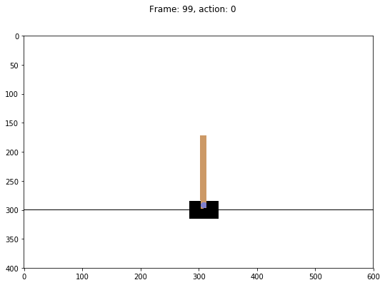

```python
env = gym.make('CartPole-v0')
state = env.reset()

prob_rand_action = 0.4

frame = 0

fig = plt.figure(figsize = (9,6))
img = plt.imshow(env.render(mode = 'rgb_array'))

for _ in range(100):
    img.set_data(env.render(mode = 'rgb_array'))
    display.display(plt.gcf())
    display.clear_output(wait = True)

    if np.random.random(1)[0] < prob_rand_action:
        action = env.action_space.sample()
    else:
        Q_pred = sess.run(Q, feed_dict = {ph_states: state[np.newaxis,:]})
        action = np.argmax(Q_pred,1)[0]

    state, reward, done, _ = env.step(action)

    if abs(state[0]) > 2.7 or abs(state[2]) > 0.45:
        state = env.reset()
        frame = 0

    fig.suptitle('Frame: {}, action: {}'.format(frame,action))
    frame += 1

env.close()
```

```python
%%javascript
$.getScript('https://kmahelona.github.io/ipython_notebook_goodies/ipython_notebook_toc.js')
```